# Exploring Quantitative Variables: IMDb Movie Reviews

Your Name: _______________

September 26, 2022

[figure not shown]

[figure not shown]

[figure not shown]

[figure not shown]

## Learning outcomes

- Identify and create appropriate summary statistics and plots given a data set or research question for quantitative data.
- Interpret the following summary statistics in context: median, first quartile, third quartile, standard deviation, interquartile range.
- Identify and create appropriate summary statistics and plots given a data set or research question for a single quantitative variable.
- Given a plot or set of plots, describe and compare the distribution(s) of a single quantitative variable (center, variability, shape, outliers).

## Terminology review

In today’s activity, we will review summary measures and plots for quantitative variables. Some terms covered in this activity are:

- Two measures of center: mean, median
- Two measures of spread (variability): standard deviation, interquartile range (IQR)
- Types of graphs: box plots, dot plots, histograms

## Movies released in 2020

A data set was collected on movies released in 2020. Here is a list of some of the variables collected on the observational units (each movie):

| **Variable** | **Description** |
| --- | --- |
| `Movie` | Title of the movie |
| `averageRating` | Average IMDb user rating score from 1 to 10 |
| `numVotes` | Number of votes from IMDb users |
| `Genre` | Categories the movie falls into (e.g., Action, Drama, etc.) |
| `2020 Gross` | Gross profit from movie viewing |
| `runtimeMinutes` | Length of movie (in minutes) |

The code below `head()` shows us the top 6 observational units in the movie data set.

```r
head(movie_ratings)
```

| Movie | Genre | 2020 Gross | runtimeMinutes | averageRating | numVotes |
| --- | --- | --- | --- | --- | --- |
| 1917 | Thriller/Suspense | 157901466 | 34 | 5.7 | 23 |
| The Invisible Man | Horror | 64914050 | 71 | 7.7 | 29256 |
| The Call of the Wild | Adventure | 62342368 | 16 | 5.3 | 51 |
| Tenet | Action | 58044165 | 150 | 8.2 | 10174 |
| Halloween | Horror | 47274000 | 91 | 7.8 | 222169 |
| Little Women | Drama | 37593127 | 60 | 6.5 | 34 |

## Visualizing a Single Quantitative Variable

1. What are the three types of plots used to plot a single quantitative variable?

## Dotplot

A dotplot will plot a dot for each value in the data set. The code below was used to create a dotplot of the `averageRatings` variable from the `movies` dataset. In a dotplot, the quantitative variable goes on the x-axis, which is why the code says `x = averageRating` inside of the `aes()` function.

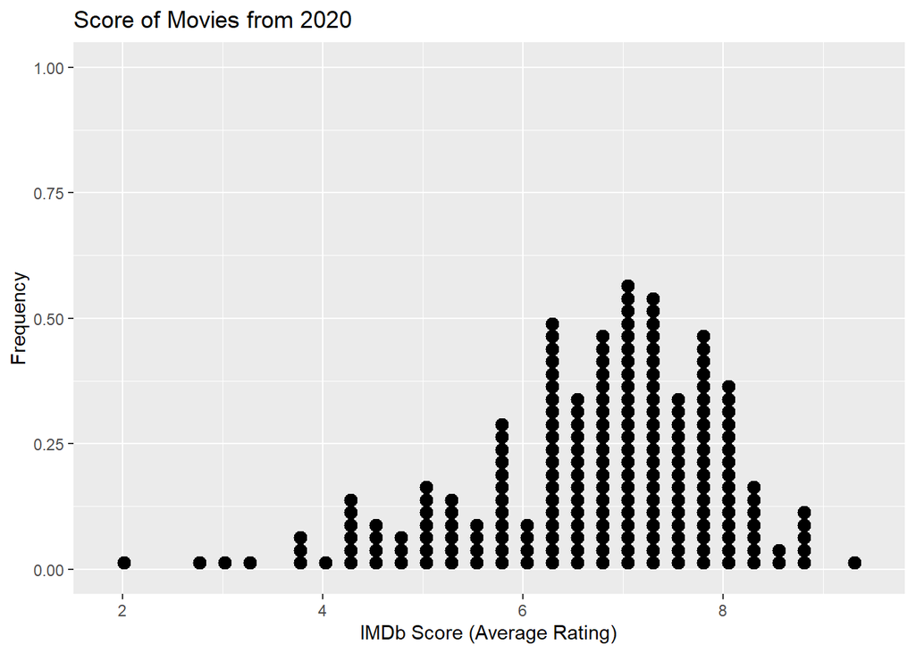

```r
ggplot(data = movie_ratings,
       mapping = aes(x = averageRating)) +
  geom_dotplot(dotsize = 0.5, method="histodot") +
  labs(title = "Score of Movies from 2020", # Title for plot
       x = "IMDb Score (Average Rating)", # Label for x axis
       y = "Frequency" # Label for y axis
       )
```

2. What does each dot on the dotplot represent?
3. How would you describe the shape of the distribution of IMDb scores?
4. What do you think `dotsize = 0.5` in the code chunk does?

## Histogram

To create a histogram of the IMDb scores, all we need to do is change the geometric object we are displaying on our plot! In a dotplot we use dots, but in a histogram we use bars. Notice, in the code below there are two changes:

- I am using `geom_histogram()` instead of `geom_dotplot()`
- I am specifying how wide the bins of the histogram should be using `binwidth = 0.5`

[figure not shown]

```r
ggplot(data = movie_ratings,
       mapping = aes(x = averageRating)) +
  geom_histogram(binwidth = 0.5) +
  labs(title = "Score of Movies from 2020", # Title for plot
       x = "IMDb Score (Average Rating)", # Label for x axis
       y = "Frequency" # Label for y axis
       )
```

5. Why did I **not** need to specify a `binwidth` in the dot plot I made?
6. Which range of IMDb scores have the *highest* frequency?
7. What IMDB scores are movies *rarely* rated?
8. Are there IMDB scores that were possible but *no* movies in this sample were given those ratings?

## Boxplot

9. Which five summary statistics are used to create a box plot?

```r
summarize(movie_ratings,
          min_score = min(averageRating),
          Q1_score = quantile(averageRating, 0.25),
          median_score = median(averageRating),
          Q3_score = quantile(averageRating, 0.75),
          max_score = max(averageRating)
          )
```

| min_score | Q1_score | median_score | Q3_score | max_score |
| --- | --- | --- | --- | --- |
| 1.9 | 6.1 | 7 | 7.6 | 9.2 |

10. Using the summary statistics provided, sketch a box plot of IMDb scores. Be sure to label the axes!
11. How do you decide if a value is an “outlier” when creating a boxplot?

In the code below, I’m providing you with the top 6 and the bottom 6 IMDb scores.

**Bottom 6:**

```r
movie_ratings %>%
  select(averageRating) %>%
  slice_min(order_by = averageRating, n = 6)
```

| averageRating |
| --- |
| 1.9 |
| 2.7 |
| 2.9 |
| 3.3 |
| 3.7 |
| 3.9 |
| 3.9 |

**Top 6:**

```r
movie_ratings %>%
  select(averageRating) %>%
  slice_max(order_by = averageRating, n = 6)
```

| averageRating |
| --- |
| 9.2 |
| 8.9 |
| 8.7 |
| 8.7 |
| 8.7 |
| 8.7 |

12. Revisit your previous boxplot to decide if any observations should be plotted as outliers.

(Modify your previous plot)

## Plot Comparison

13. Compare the three graphs of IMDb scores created above.
- Which graph(s) show the shape of the distribution?
- Which graph(s) show the outliers of the distribution?
- Which graph plots the *raw* data (individual observations)?

## Summarizing a single quantitative variable

14. Based on the distributions provided, do you believe the *mean* IMDb score will be greater or less than the median? Explain why!

In the code below I’ve calculated the standard deviation of the IMDb scores.

```r
summarize(movie_ratings,
          sd_score = sd(averageRating)
          )
```

| sd_score |
| --- |
| 1.252082 |

15. Interpret the value of the standard deviation in the context of these data.

### Take-Home Messages

- Histograms, box plots, and dot plots can all be used to graphically display a single quantitative variable.
- The box plot is created using the five number summary: the minimum value, Q1, median, Q3, and the maximum value. Values in the data set that are less than $Q_1 - 1.5*\text{IQR}$ and greater than $Q_3 + 1.5*\text{IQR}$ are considered outliers and are graphically represented by a dot outside of the whiskers on the box plot.
- Data should be summarized numerically **and** displayed graphically to give us information about the study.
- When comparing distributions of quantitative variables we look at the shape, center, spread, and for outliers. There are two measures of center: mean and the median and two measures of spread: standard deviation and the interquartile range, $\text{IQR} = Q3 - Q1$.